# Bilan IA

V. GUERIN - T. DEMESSE - B. SAUZE

07-05-2020

# **Nos essais :**

## *Domaine*

Notre reconnaissance d’image est basée sur l’identification de 2 nuisibles, en plus d’un prédateur permettant de limiter l’impact des ravageurs.

## *Catégories*

Nous avons opté pour 3 catégories :

- Le cafard
- La mouche
- L’araignée

## *Constitution du corpus d’apprentissage*

Nous avons récupéré les 100 premières images de la requête google pour “flie”, “spider” et “cockroach”

```r
#query = ["flie", "cockroach", "spider"]
```

Les images ainsi téléchargées sont triées manuellement car les moteurs de recherche sortent des images qui ne correspondent pas à la requête, de facon à tromper les algorithmes de Deep Learning qui tenteraient de passer par ces moteurs de recherche.

Les image correspondent globalement, mais après plusieurs résultats, il y a de plus en plus d’images qui ne sont pas directement associées a la requête.

On place ensuite 80% des images dans un dossier “training” qui constitue la base d’entraînement du réseau neuronal. On compare ensuite la correspondance avec les 20% d’images placées dans un dossier “test”. Le réseau ainsi créé est basé sur l’association des images du dossier test avec celles du dossier “training” pour lesquels nous sommes assurés de la correspondance.

## *Réseau neuronal*

On teste l’efficacité de notre réseau neuronal avec 10 passes d’apprentissage à partir du corpus d’images initialement créé.

La sortie python obtenue sur le test du réseau nous donne ceci :

```r
#CNN  multiclass  ( 3 catégories)
#cockroach  :  17 / 20 ( 85 %)
#flie  :  4 / 12 ( 33 %)
#spider  :  9 / 11 ( 81 %)
#Global :  30 / 43 ( 69 %)
```

On arrive à une reconnaissance globale de 69% des images. Avec un bon discernement des cafards et des araignées, mais pas des mouches.

Lorsque l’on observe la base d’apprentissage, on peut expliquer le faible taux de reconnaissance des mouches par une variabilité des clichés en terme de fond, d’angles de vue et de type de mouches. Contrairement aux images de cafards et d’araignées qui sont plus homogènes.

# **Étude des réseaux précédement créés:**

## En fonction du nombre de passes

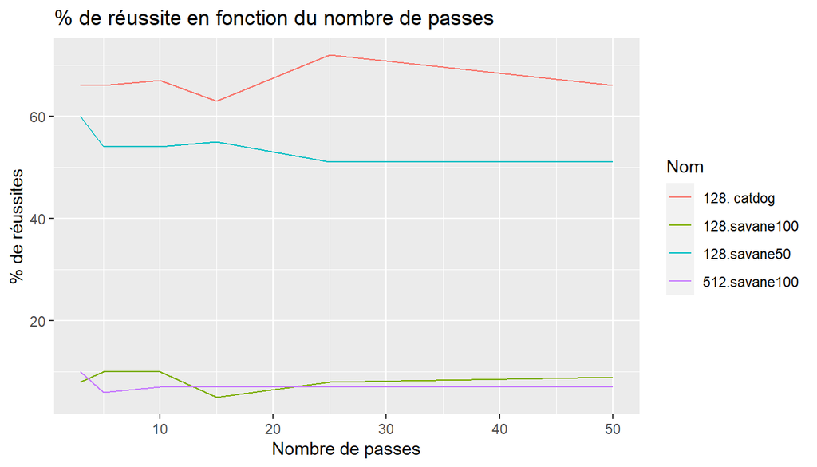

```r
library(ggplot2)
library(dplyr)

models <- read.csv("models.csv")

models$Nom <-paste(models$Nombre.de.neurones.dans.la.couche.complètement.connectée,
                   models$Dataset.d.entraînement,sep=".")

filter(models, Nom %in% c("128. catdog", "128.savane50", "128savane100", "512.savane100"))

models %>%
  ggplot( aes(x=Nombre.passes, y=Pourcentage.de.réussite, group=Nom, color=Nom)) +
  geom_line() +
  ggtitle("% de réussite en fonction du nombre de passes") +
  ylab("% de réussites")+
  xlab("Nombre de passes")
```

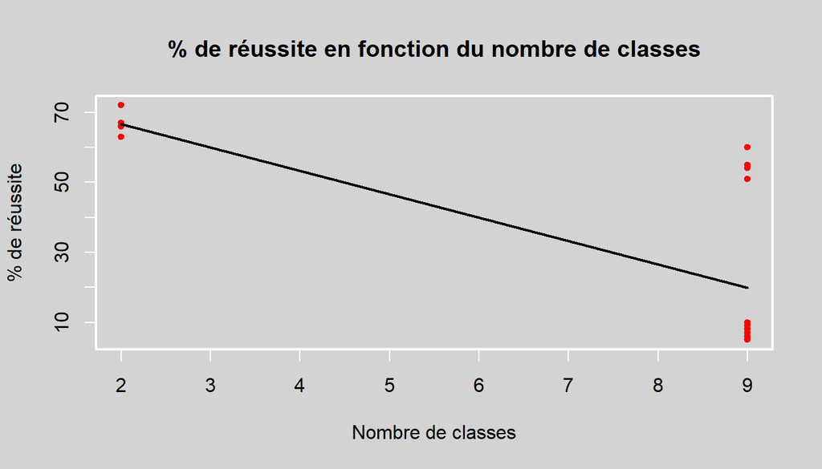

```r
models <- read.csv("models.csv")

 op <- par(bg = "lightgrey", fg = "white", lwd = 2)

 plot(models$Nombre.de.classes, models$Pourcentage.de.réussite,
      pch = 20, cex = 0.8, col = "red",
      xlab = "Nombre de classes",
      ylab = "% de réussite")

 lines(lowess(models$Nombre.de.classes, models$Pourcentage.de.réussite), col = "black")
 title("% de réussite en fonction du nombre de classes")
```

Les ensembles de classes 9 ont donc un pourcentage de réussite très hétérogène qui se distinguent en 2 clusters, bien identifiables sur ce graphique. Tandis que les ensembles de classe 2 sont bien plus homogènes.

# Cependant, au vu des fortes disparités de représentativité des nombres de classes (3 fois plus de classes 9 que de classe 2), l’influence de ce paramètre est partagée entre plusieurs autres facteurs, ce que nous permet de constater une ACP de ces données…

## En fonction du nombre d’images d’entraînement

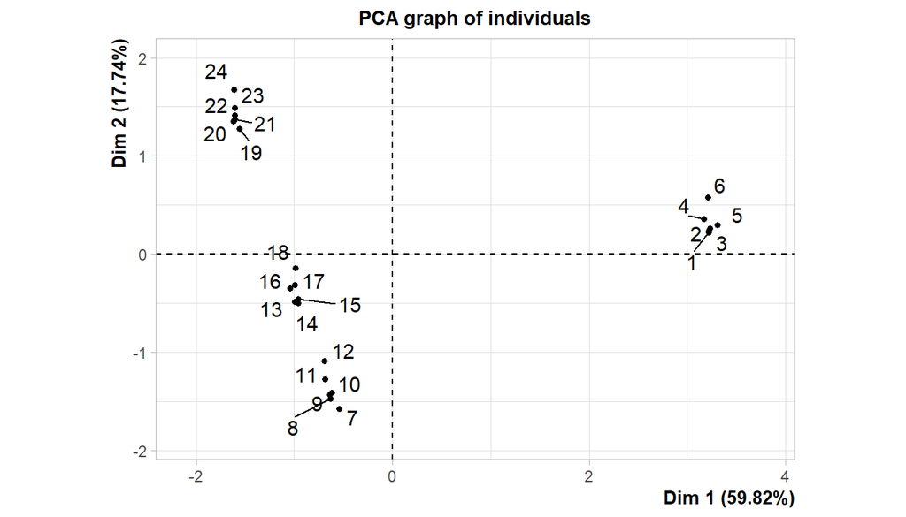

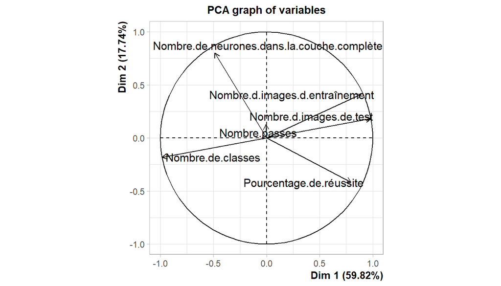

```r
library("FactoMineR")
library("factoextra")

models <- read.csv("models.csv")

models$Dataset.d.entraînement <- NULL
models$Dataset.de.test <- NULL

res.pca <- PCA(models, graph = TRUE)
```

On observe grâce au cercle des corrélation que le nombre de classe est corrélé négativement avec le pourcentage de réussite ce qui est visible dans les premiers graphiques générés ci-dessus.

On remarque en revanche que les variables telles que le nombre d’images d’entraînement et le nombre d’images test sont correlés positivement avec un poids important vis-à-vis du pourcentage de réussite, donc ils influent fortement sur ce dernier.

En une phrase : plus le nombre d’images dans la base est important plus la réussite du test est élevée.